# ATAC_seq_2

David Oliver

November 12, 2017

# 1. ATAC-seq QC

The QC that has been performed up to this point has been to assess the quality of the experiment, sequencing, and the alignment.

```r
# load in the packages we will need
library(edgeR)                              # for differential expression analysis
library(magrittr)                           # for the pipe function
library(knitr)                              # making pretty tables
library(ATACseqQC)                          # for doing..ATAC-seq QC...
library(MotifDb)                            # motif database
library(ChIPpeakAnno)                       # provides functionality for peak data in R
library(RColorBrewer)                       # better color schemes
library(TxDb.Hsapiens.UCSC.hg38.knownGene)  # Transcript annotation for hg38
library(phastCons100way.UCSC.hg38)          # conserved sequence annotation for hg38
library(BSgenome.Hsapiens.UCSC.hg38)        # hg38 in biostrings format
library(GenomicAlignments)                  # provides functionality for genomic alignments

# read in the counts per peak (from the featureCounts step)
counts <- read.delim("R/Peak_counts.txt", skip = 1)

# fix the names
sample_names <-
    strsplit2(colnames(counts), split = "\\.")[-(1:6), 7] %>%
    strsplit2(., "_") %>%
    .[, 1]
colnames(counts) <- c(strsplit2(colnames(counts), split = "\\.")[1:6, 1], sample_names)

# fixing names is like 90% of your job as a bioinformatician, the rest is easy
counts$Geneid <-
    strsplit2(counts$Geneid, split = "_")[, 7:8] %>%
    apply(., 1, paste, collapse = "_") %>%
    make.names(., unique = T)

kable(head(counts))
```

| Geneid | Chr | Start | End | Strand | Length | SRR4044835 | SRR4044837 |
| --- | --- | --- | --- | --- | --- | --- | --- |
| peak_1 | chr1 | 10063 | 10455 | + | 393 | 87 | 49 |
| peak_2 | chr1 | 180767 | 181792 | + | 1026 | 93 | 93 |
| peak_3 | chr1 | 629693 | 630021 | + | 329 | 1380 | 619 |
| peak_4 | chr1 | 633901 | 634230 | + | 330 | 2160 | 1083 |
| peak_5 | chr1 | 778400 | 779119 | + | 720 | 205 | 121 |
| peak_6 | chr1 | 789662 | 790770 | + | 1109 | 83 | 26 |

There are a lot of advantages to working with data in this format. The main thing is that there are a LOT of tools already developed to handle these types of data.

Looking at some summary statistics.

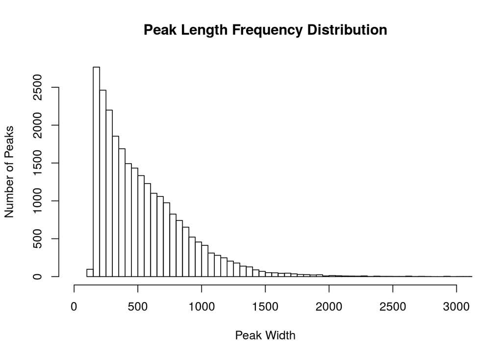

```r
# plot the peak size distribution (frequency)
hist(x = counts$Length,
     xlim = c(0,3000),
     breaks = 100,
     freq = T,
     main = "Peak Length Frequency Distribution",
     xlab = "Peak Width",
     ylab = "Number of Peaks")
```

```r
# make a summary table
summary(counts$Length) %>%
    t() %>% t() %>%
    kable(., col.names = "Peaks Length")
```

|  | Peaks Length |
| --- | --- |
| Min. | 142.0000 |
| 1st Qu. | 272.0000 |
| Median | 455.0000 |
| Mean | 541.9524 |
| 3rd Qu. | 716.0000 |
| Max. | 6763.0000 |

## A. Fragment Size Distribution

If we want to get a more fine grained look at these data we can look directly at the fragment (reads) sizes from the BAM files.

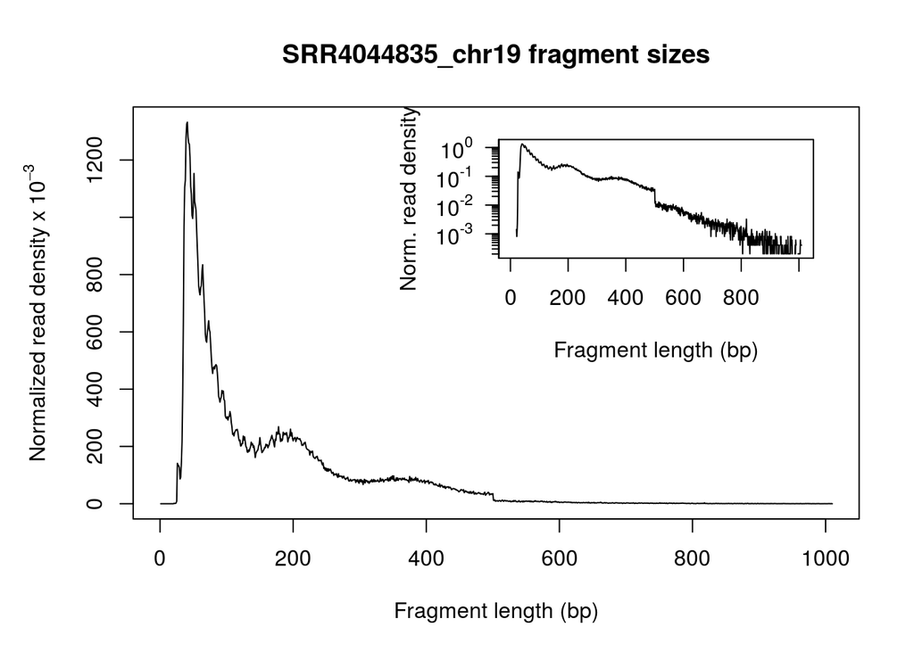

```r
# location of the BAM files
bamfiles <- dir(path = "R", pattern = "*.bam$", full.names = T)

# names of the BAM files
bamfile_labels <- strsplit2(dir(path = "R", pattern = "*.bam$"), "\\.")[,1]

# calculate fragment sizes and plot them.
fragSizeDist(bamfiles[1], bamfile_labels[1])
```

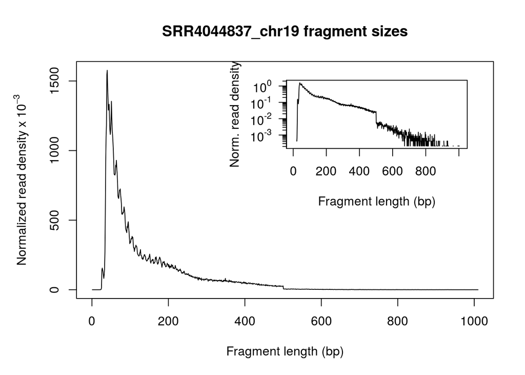

```r
fragSizeDist(bamfiles[2], bamfile_labels[2])
```

SRR4044835 (Day 28) seems to be a better experiment, most likely due to higher depth of sequencing and larger FRiP.

Fragment size is the primary reason that ATAC-seq is performed with paired end sequencing. Without paired ends there is no way to get exact fragment size data.

## B. Nucleosome Position at TSSs

From Fragment sizes nucleosome positioning around can be calculated.

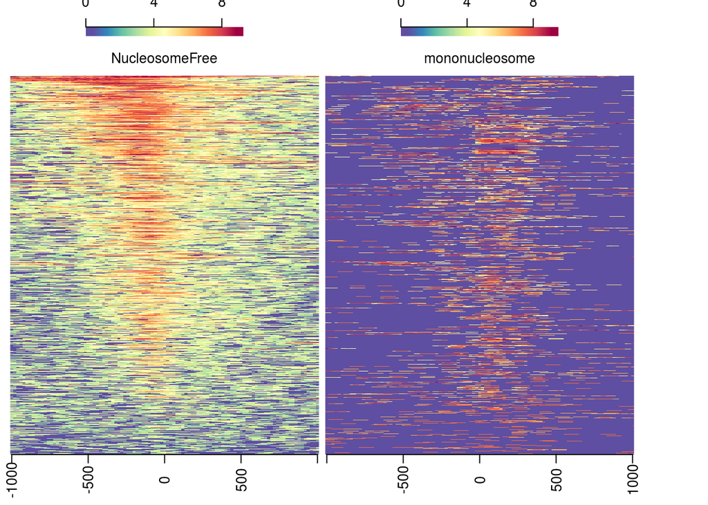

```r
# get sequence information for chr19 from hg38
chr19_seq <- as(seqinfo(Hsapiens)["chr19"], "GRanges")

# get transcripts from hg38 UCSC annotation
chr19_transcripts <-
    transcripts(TxDb.Hsapiens.UCSC.hg38.knownGene) %>%
    .[seqnames(.) %in% "chr19"]

# from transcript annotation pull just the transcription start site
TSS <-
    promoters(chr19_transcripts, upstream = 0, downstream = 1) %>%
    unique()

# calculate the library size for SRR4044835_chr19
librarySize <- estLibSize(bamfiles[1])

##################################################
# This section takes a while to run so it was
# pre-run and the output saved as an R object
# using the saveRDS() function
##################################################
# SRR4044835_chr19 <-
#     readBamFile(bamfiles[1], which = chr19_seq, asMates = T) %>%
#     shiftGAlignmentsList() %>%
#     splitGAlignmentsByCut(.,
#                           txs = chr19_transcripts,
#                           genome = Hsapiens,
#                           conservation = phastCons100way.UCSC.hg38)
#
# signals <- enrichedFragments(gal = SRR4044835_chr19[c("NucleosomeFree", "mononucleosome",
#                                                       "dinucleosome", "trinucleosome")],
#                             TSS         = TSS,
#                             librarySize = librarySize,
#                             seqlev      = "chr19",
#                             TSS.filter  = 0.5,
#                             n.tile      = 101,
#                             upstream    = 1010,
#                             downstream  = 1010)
# saveRDS(signals, file = "R/signals.rds")

# load in the pre-built signals object
signals <- readRDS(file = "R/signals.rds")

# log transform the signal at TSSs for better visualiztion
log_signals <- lapply(signals, function(x) log2(x+1))

# now generate the heatmap for open chromatin signal around TSSs
featureAlignedHeatmap(log_signals,
                      reCenterPeaks(peaks = TSS, width = 1010*2),
                      zeroAt = 0.5,
                      n.tile = 101,
                      color = rev(brewer.pal(11, "Spectral")))
```

The nucleosome free fragments is shifted upstream of the TSS while the mononucleosomal fragments are shifted slightly downstream.

Using a density plot can often be more informative than the much prettier heatmap.

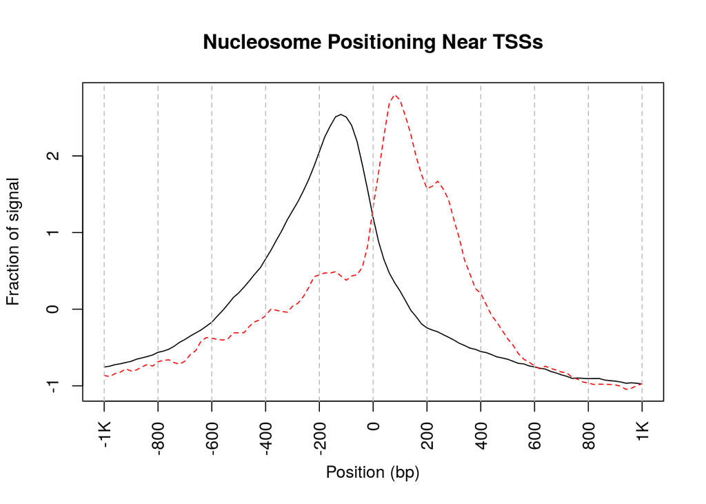

```r
# plot the density of nucleosome free vs mononucleosome signals
matplot(out,
        type = "l",
        xaxt = "n",
        xlab = "Position (bp)",
        ylab = "Fraction of signal",
        main = "Nucleosome Positioning Near TSSs")

# pretty x-axis
axis(1, at = seq(0, 100, by=10)+1,
     labels = c("-1K", seq(-800, 800, by=200), "1K"),
     las = 3)

# add some verticle lines for easier visualiztion
abline(v = seq(0, 100, by = 10)+1,
       lty = 2,
       col = "gray")
```

Looking at the full dataset, the nucleosome free region peaks about 0-50bp upstream of the transcription start site with a strong valley in the corresponding nucleosome signal.

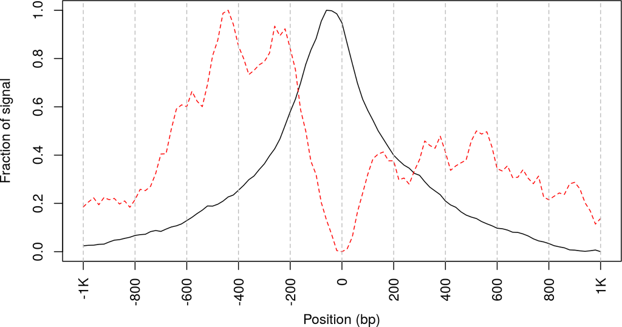

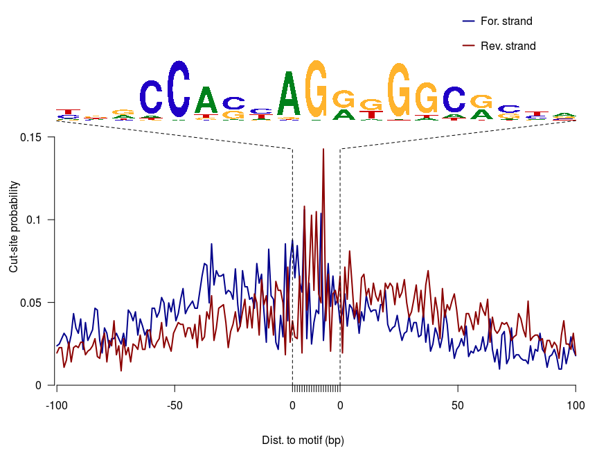

ATAC-seq signal at CTCF motifs on chr19

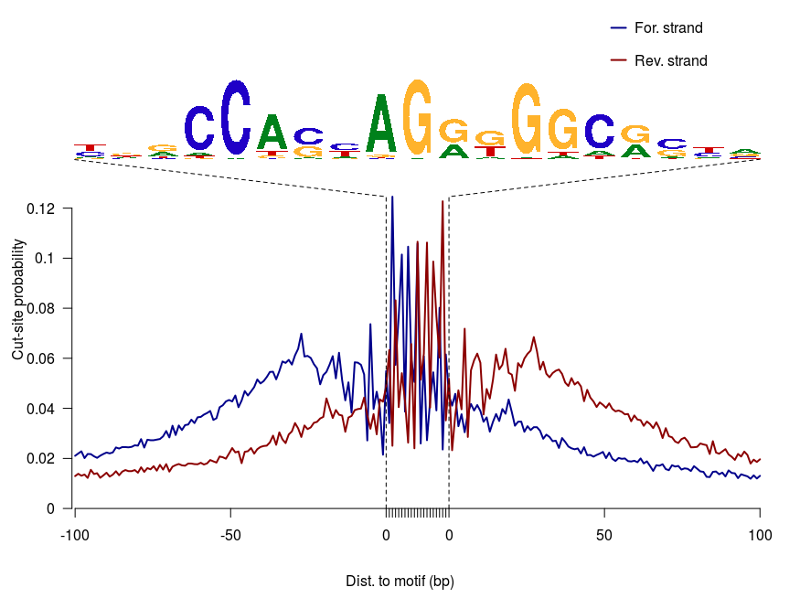

ATAC-seq signal at CTCF motifs over the whole genome

The signal doesn’t look great. CTCF is a common control motif because it is well studied and known to produce a characteristic value with low signal at the binding site and strong signal adjacent to it. This, more or less, reiterates that the experiment could significantly benefit from additional sequencing.

# 2. Differentially Open Chromatin

Now that things look copacetic, differentially open chromatin regions can be called. The hypothesis is that HDAC inhibitors should prevent the closure of chromatin.

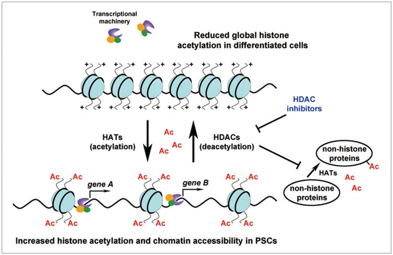

Wang, Yu-Chieh et al. Cell research. 24. 2013).

## A. Looking at MACS2 Peaks

First let’s look at the differentially called peaks. Go to [UCSC’s genome browser](https://genome.ucsc.edu/). Under `MyData` select `Custom Tracks`. Above the first empty box select `Choose File`. From the `Desktop/ATAC_Seq/R` directory select the `.bed` files from `macs2 bdgdiff` function. `Chr19_Diff_Open_Chromatin*` and click submit. Do this for all 3 files.

Change the name by clicking the `Track Name` link and change `cond1` to `Romi_Day28` and `cond2` to `Romi_Day0`

Finally click the `go` button next to the `Genome Browser` dropdown menu.

Play around with looking at a few of the Differentially Open Regions.

## B. Quantifying Differentially Open Regions

`MACS2` reports a Likelihood ratio but no other statistics for each peak. To get a better quantification, call differentially open peaks with `edgeR`

```r
#read in the data (chr19 only)
x <-
    read.delim("R/Chr19_Peak_counts.txt", header = T, comment.char = "#")
x_meta <- x[,2:6]
rownames(x) <-
    strsplit2(x$Geneid, "_")[,8:9] %>%
    apply(., 1, paste, collapse = "_")
x <-
    x[,-(1:6)] %>%
    `colnames<-` (., c("Day28", "Day0"))

group <- factor(colnames(x))
bcv = 0.4
y <-
    DGEList(counts = x, group = group, genes = x_meta) %>%
    calcNormFactors()
et <- exactTest(y, dispersion = bcv^2)
topTags(et)
```

```
## Comparison of groups:  Day28-Day0
##        Chr    Start      End Strand Length     logFC   logCPM       PValue
## 580  chr19 22797799 22798243      +    445 -5.205002 6.939465 0.0002035688
## 1340 chr19 47822905 47823070      +    166 -5.061203 6.808605 0.0003413831
## 436  chr19 16383419 16383641      +    223  7.338561 6.844072 0.0013911548
## 991  chr19 34922273 34922430      +    158 -4.622847 6.428266 0.0013911548
## 1186 chr19 41645010 41645234      +    225 -3.620195 7.286533 0.0014587634
## 90   chr19  2360301  2360530      +    230 -3.922031 6.649365 0.0036526097
## 164  chr19  4872753  4872968      +    216  6.978536 6.554071 0.0036800287
## 296  chr19 10767057 10767304      +    248 -3.695246 6.969392 0.0039156420
## 860  chr19 26861939 26862103      +    165 -2.948639 7.480365 0.0050150080
## 973  chr19 34079357 34079648      +    292 -2.948639 7.480365 0.0050150080
##            FDR
## 580  0.2737893
## 1340 0.2737893
## 436  0.4679713
## 991  0.4679713
## 1186 0.4679713
## 90   0.7602487
## 164  0.7602487
## 296  0.7602487
## 860  0.7602487
## 973  0.7602487
```

Look at these peaks in Genome Browser and see what they are associated with. Notice that many of these will not have corresponding `MACS2` differential peaks. Additionally, although `MACS2` called differential peaks it’s hard to tell what is a real differential peak.

The next section (Yurii’s ChIP-seq section) will look at how to annotate peaks and additional analysis that can suppliment differentially open chromatin analyses.